# Explorando o mercado de capitais em R

Helson Gomes de Souza

2025-01-01

# Introdução

Na área de finanças, conhecer as cotações e as tendências do mercado de capitais é fundamental para uma tomada de decisão eficiente. Bancos, corretoras e intermediadoras financeiras geralmente dispõem de ferramentas que auxiliam o tomador de decisão quanto à escolha de ativos por meio de gráficos de cotações e indicadores financeiros. Contudo, essa tarefa pode ser facilmente executada na linguagem *R* usando a biblioteca *quantmod* e bibliotecas auxiliares. O objetivo desse post é mostrar como essa biblioteca pode auxiliar na análise financeira, no aprendizado e na resolução de problemas referentes ao mercado de capitais.

# Importando dados do mercado de capitais

O primeiro passo para explorar os dados do mercado de capitais é instalar e liberar a biblioteca.

```r
#install.packages("quantmod")
library(quantmod)
```

```r
getSymbols("VALE3.SA")
```

```
FALSE [1] "VALE3.SA"
```

O resultado é um dataframe com o preço de abertura *“VALE3.SA.Open”*, o preço máximo *“VALE3.SA.High”*, o preço mínimo *“VALE3.SA.Low”*, o preço de fechamento *“VALE3.SA.Close”*, o volume negociado *“VALE3.SA.Volume”* e o preço ajustado no *after market* *“VALE3.SA.Adjusted”*.

Um gráfico simples da série pode ser gerado com o seguinte comando:

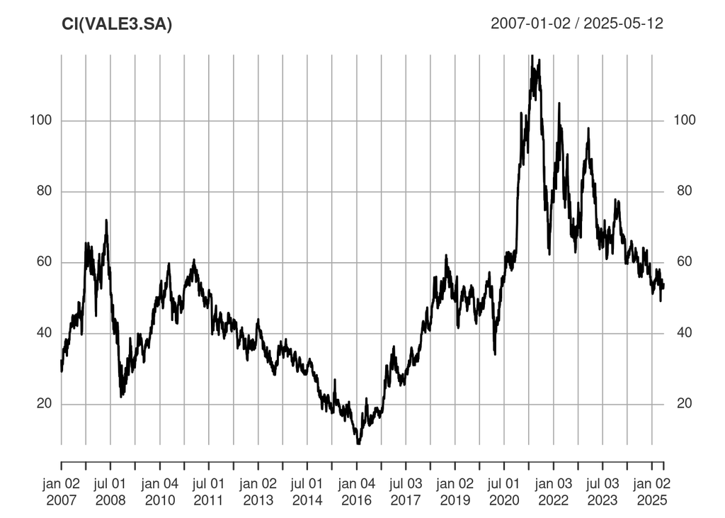

```r
plot(Cl(VALE3.SA), col = 'black')
```

# Visualizando os dados

Um gráfico de velas pode ser elaborado usando a função *candleChart*. Para facilitar a visualização, considere representar na figura apenas o ano de 2023.

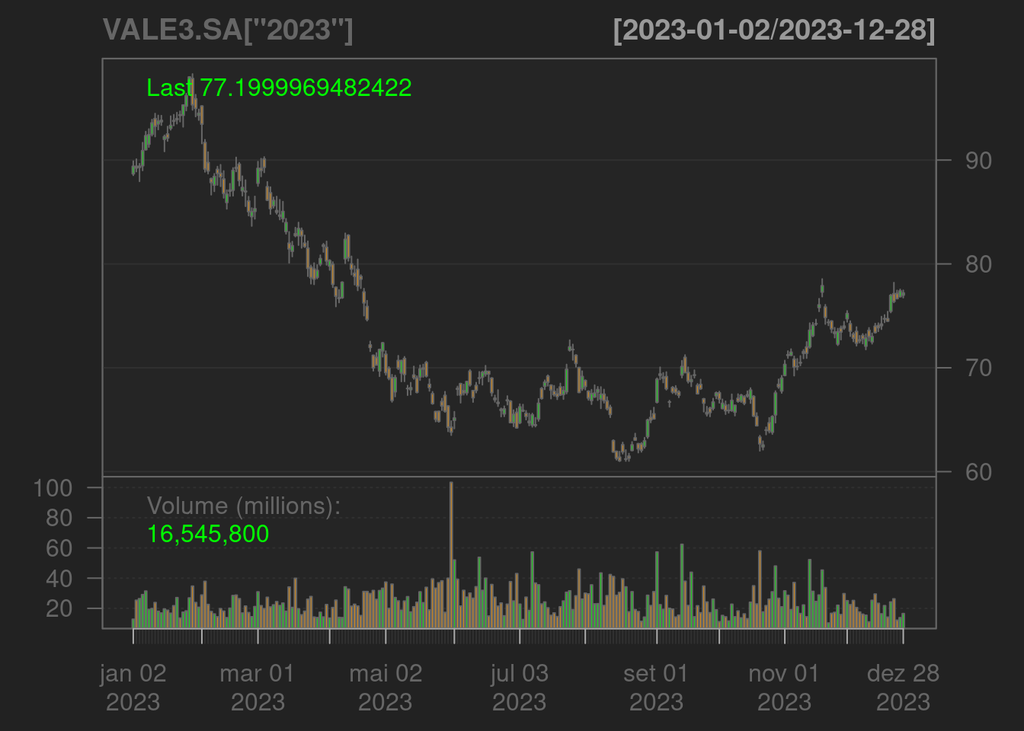

```r
candleChart(VALE3.SA["2023"])
```

A biblioteca dispões de temas prontos que facilitam a visualização das cotações e personalizam a figura gerada. Por exemplo:

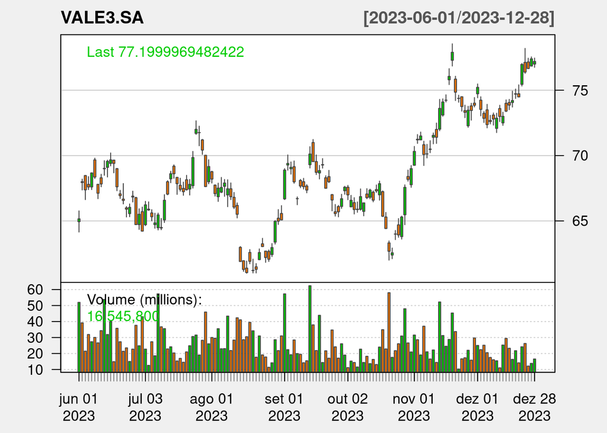

```r
candleChart(
  VALE3.SA,
  theme = "white",
  subset = '2023-06::2023-12'
)
```

Agora considere que seja interessante mudar a cor dos candles de acordo com a variação da cotação, de modo que, caso a cotação suba, então o candle deve ter cor azul e caso a cotação caia o candle deve ter cor vermelha. Nesse caso, deve-se proceder da seguinte maneira:

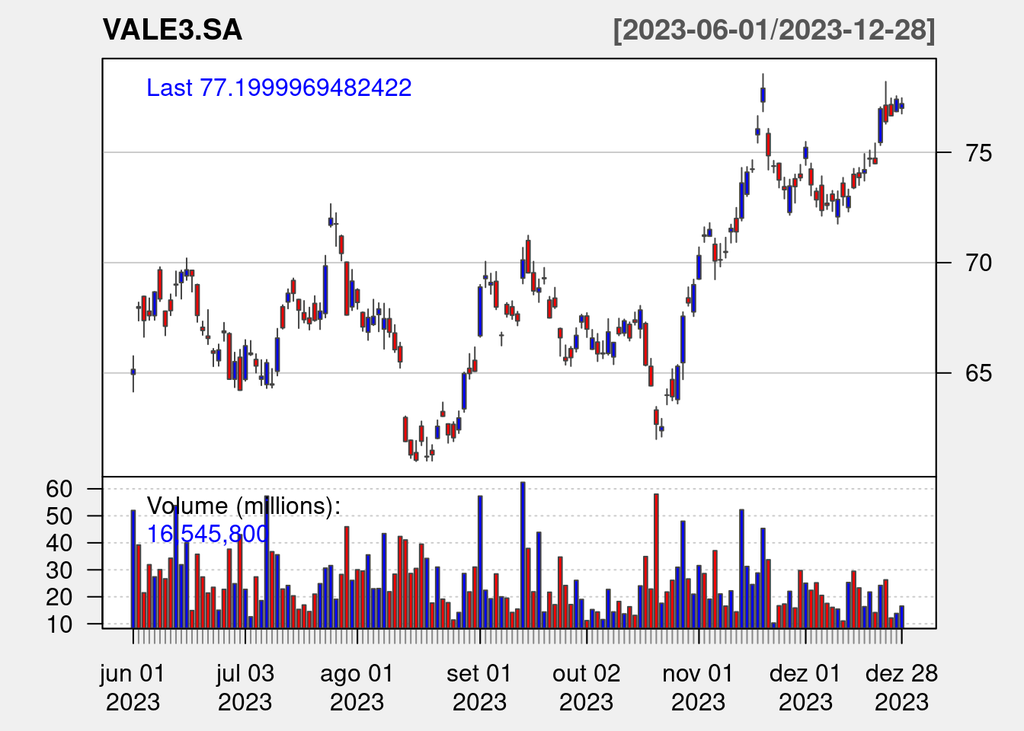

```r
candleChart(
  VALE3.SA,
  theme = chartTheme("white", up.col = "blue", dn.col = "red"),
  subset = '2023-06::2023-12'
)
```

Alguns indicadores podem ser incluídos na figura. Por exemplo, uma média móvel pode ser adicionada com a função *addSMA*, que deve ser requerida logo após a geração do gráfico de velas. No caso de uma média móvel de sete semanas, deve-se proceder como:

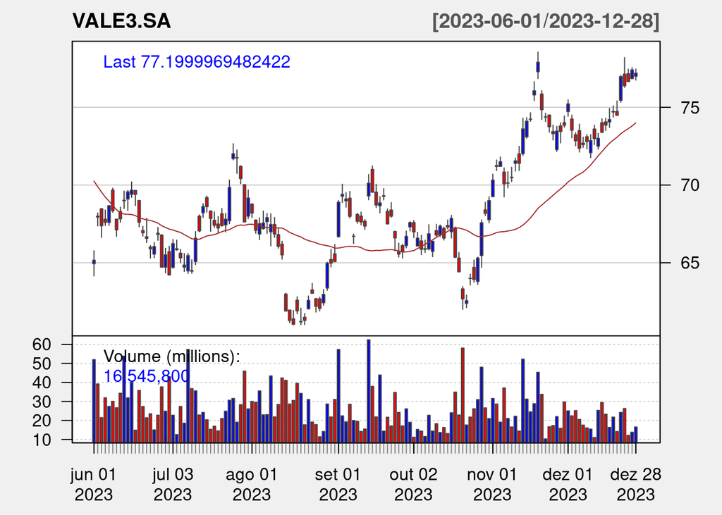

```r
addSMA(n = 7*5)
```

Use a função *addBBands()* para adicionar bandas de bollinger ao gráfico de velas.

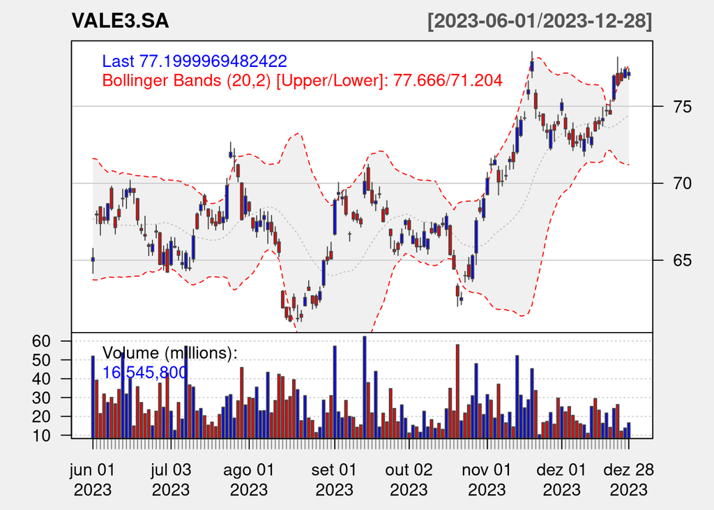

```r
addBBands()
```

# Conclusões

A linguagem *R* dispõe de ferramentas bastante úteis para lidar com o mercado de capitais e a biblioteca *quantmod* é uma das mais completas e eficientes na parte de visualização dos dados. Maiores detalhes podem ser consultados em https://www.quantmod.com/.

# Referências

quantmod. **Quantitative Financial Modelling & Trading Framework for R**. https://www.quantmod.com/.